# Exercise 3.1.5

# 1 Question

Exercise 3.1.5 Alter the data to k = 99 and n = 100, and comment on the shape of the posterior for the rate $\theta$.

# 2 Comments/Solution

Comparing at the posterior distributions (from the plots section below) of k=99, n=100 to the previous distribution of k=50, n=100, one can observe that the $\theta$ estimates have shifted towards the extreme right of the graph to a value very close to 1 with slight uncertanity. Since the data shows that 99 times out of 100 we get a positive, the posterior has very little doubt as to where the real value lies.

# 3 Code

## 3.1 libraries

The libraries required for the script and the plots.

```r
# clears workspace
rm(list=ls())
#load libraries
library(rstan)
library(ggplot2)
library(patchwork)
```

## 3.2 Data

The data required for this particular stan model.

```r
# data  initialization
k <- 50
n <- 100
k_1 <- 99
n_1 <- 100
# to be passed on to Stan
stan_data <- list(k = k, n = n)
stan_data_1 <- list(k = k_1, n = n_1)
```

## 3.3 Stan code

Stan code, that can be written in R as such or in a seperate new file with stan extension.

```r
write("// Stan code here in this section

// Inferring theta
data {
  int<lower=1> n;
  int<lower=0> k;
}
parameters {
  real<lower=0,upper=1> theta;
}
model {
  // Prior Distribution for theta
  theta ~ beta(1, 1);

  // Observed Counts
  k ~ binomial(n, theta);
} // ",

"3_1_5.stan")
```

## 3.4 code in R to run stan

Running stan through R (with the required input parameters).

```r
myinits <- list(
  list(theta=.1),  # chain 1 starting value
  list(theta=.9))  # chain 2 starting value

# parameters to be monitored:
parameters <- c("theta")

# The following command calls Stan with specific options.
# For a detailed description type "?stan".
mod_fit <- stan(file="3_1_5.stan",
                data=stan_data,
                init=myinits,  # If not specified, gives random inits
                pars=parameters,
                iter=2000,
                chains=2,
                thin=1,
                warmup=100,  # Stands for burn-in; Default = iter/2
                seed=123  # Setting seed; Default is random seed
)
mod_fit_1 <- stan(file="3_1_5.stan",
                data=stan_data_1,
                init=myinits,  # If not specified, gives random inits
                pars=parameters,
                iter=2000,
                chains=2,
                thin=1,
                warmup=100,  # Stands for burn-in; Default = iter/2
                seed=123  # Setting seed; Default is random seed
)
```

# 4 Outputs

## 4.1 Model summary

For dataset k=50 and n=100. (stan_data)

```
## Inference for Stan model: 3_1_5.
## 2 chains, each with iter=2000; warmup=100; thin=1;
## post-warmup draws per chain=1900, total post-warmup draws=3800.
##
##         mean se_mean   sd   2.5%    25%    50%    75%  97.5% n_eff Rhat
## theta   0.50    0.00 0.05   0.40   0.46   0.50   0.53   0.59  1413    1
## lp__  -71.22    0.02 0.74 -73.22 -71.38 -70.94 -70.75 -70.70  1762    1
##
## Samples were drawn using NUTS(diag_e) at Mon Oct 19 16:31:12 2020.
## For each parameter, n_eff is a crude measure of effective sample size,
## and Rhat is the potential scale reduction factor on split chains (at
## convergence, Rhat=1).
```

For dataset k=99 and n=100. (stan_data_1)

```
## Inference for Stan model: 3_1_5.
## 2 chains, each with iter=2000; warmup=100; thin=1;
## post-warmup draws per chain=1900, total post-warmup draws=3800.
##
##         mean se_mean   sd   2.5%    25%    50%   75% 97.5% n_eff Rhat
## theta   0.98    0.00 0.01   0.95   0.97   0.98  0.99  1.00  1468    1
## lp__  -10.38    0.02 0.76 -12.52 -10.57 -10.10 -9.90 -9.84  1121    1
##
## Samples were drawn using NUTS(diag_e) at Mon Oct 19 16:31:12 2020.
## For each parameter, n_eff is a crude measure of effective sample size,
## and Rhat is the potential scale reduction factor on split chains (at
## convergence, Rhat=1).
```

## 4.2 Plots

### 4.2.1 Plot (chains)

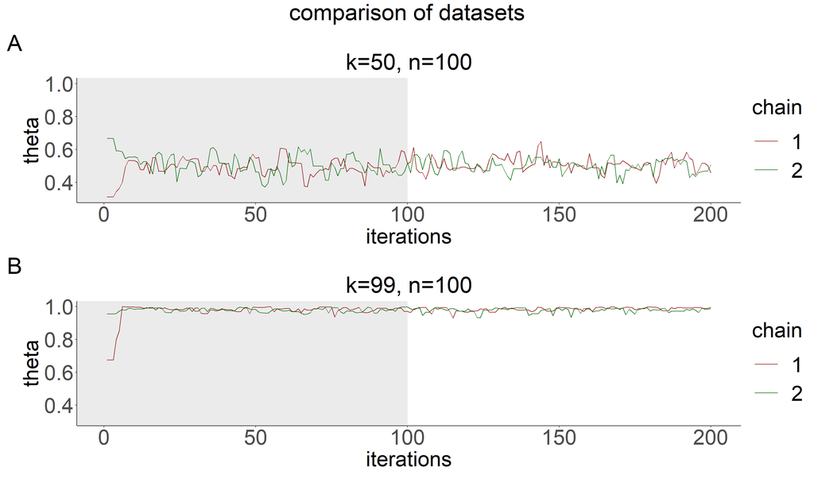

### 4.2.2 Plot (posterior)

The plot of the $\theta$ values per chain superimposed on each other.

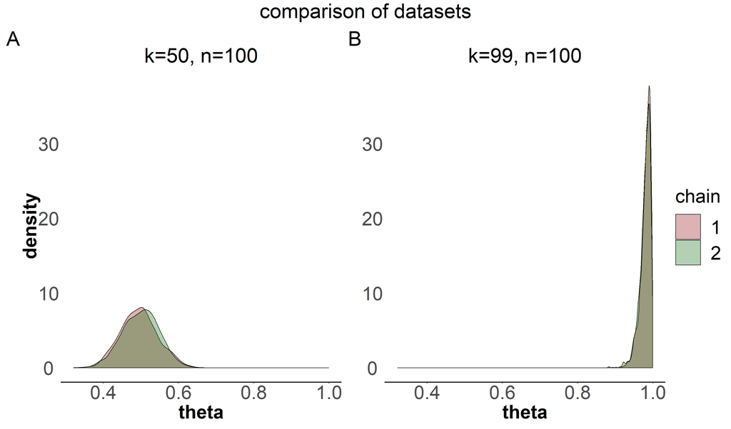